# Zadatak

Ante Jurjević

## Izabrati dataset po vlastitom izboru

Izabrao sam skup podataka o prometnim nesrećama u Barceloni 2017.godine koji je preuzet sa https://www.kaggle.com/xvivancos/barcelona-data-sets

## Odraditi EDA

```r
nesrece = read.csv("D:/Users/HPUser/Desktop/Praksa/accidents_2017.csv",encoding = "UTF-8")
```

```r
options(repos=c(CRAN="https://cloud.r-project.org/"))
install.packages("rmarkdown")
install.packages("knitr")
install.packages("ggplot2")
install.packages("DT")
library("rmarkdown")
library("knitr")
library("ggplot2")
library("DT")
library("tseries")
library("forecast")

library(tidyverse,warn.conflicts=F, quietly=T)
library(scales,warn.conflicts=F, quietly=T)
library(arules,warn.conflicts=F, quietly=T)
library(gridExtra,warn.conflicts=F, quietly=T)
library(utf8,warn.conflicts=F, quietly=T)
```

```r
summary(nesrece)
```

```
##                Id                    District.Name
##  2017S003286    :    2   Eixample           :3029
##  2017S003750    :    2   Sant Martí         :1336
##  2017S004447    :    2   Sants-Montjuic     :1104
##  2017S008856    :    2   Sarria-Sant Gervasi:1104
##  2017S000001    :    1   Horta-Guinardó     : 743
##  2017S000002    :    1   Les Corts          : 726
##  (Other)        :10329   (Other)            :2297
##                        Neighborhood.Name
##  la Dreta de l'Eixample         :1167
##  l'Antiga Esquerra de l'Eixample: 588
##  la Nova Esquerra de l'Eixample : 387
##  Sant Gervasi - Galvany         : 385
##  la Sagrada Família             : 377
##  les Corts                      : 319
##  (Other)                        :7116
##                                                 Street
##  Corts Catalanes                                   : 219
##  Diagonal                                          : 176
##  Litoral (Llobregat)                               : 116
##  Litoral (Besos)                                   :  99
##  Aragó                                             :  95
##  Meridiana                                         :  92
##  (Other)                                           :9542
##       Weekday          Month           Day             Hour
##  Friday   :1761   November: 991   Min.   : 1.00   Min.   : 0.00
##  Monday   :1510   May     : 963   1st Qu.: 8.00   1st Qu.:10.00
##  Saturday :1155   March   : 935   Median :16.00   Median :14.00
##  Sunday   : 895   October : 928   Mean   :15.78   Mean   :13.81
##  Thursday :1677   July    : 918   3rd Qu.:23.00   3rd Qu.:18.00
##  Tuesday  :1691   June    : 908   Max.   :31.00   Max.   :23.00
##  Wednesday:1650   (Other) :4696
##   Part.of.the.day Mild.injuries    Serious.injuries     Victims
##  Afternoon:5082   Min.   : 0.000   Min.   :0.00000   Min.   : 0.000
##  Morning  :4067   1st Qu.: 1.000   1st Qu.:0.00000   1st Qu.: 1.000
##  Night    :1190   Median : 1.000   Median :0.00000   Median : 1.000
##                   Mean   : 1.154   Mean   :0.02331   Mean   : 1.179
##                   3rd Qu.: 1.000   3rd Qu.:0.00000   3rd Qu.: 1.000
##                   Max.   :10.000   Max.   :4.00000   Max.   :10.000
##
##  Vehicles.involved   Longitude        Latitude
##  Min.   : 0.000    Min.   :2.092   Min.   :41.32
##  1st Qu.: 2.000    1st Qu.:2.145   1st Qu.:41.39
##  Median : 2.000    Median :2.163   Median :41.40
##  Mean   : 1.921    Mean   :2.163   Mean   :41.40
##  3rd Qu.: 2.000    3rd Qu.:2.180   3rd Qu.:41.41
##  Max.   :14.000    Max.   :2.223   Max.   :41.47
##
```

```r
datatable(head(nesrece))
```

|  | Id | District.Name | Neighborhood.Name | Street | Weekday | Month | Day | Hour | Part.of.the.day | Mild.injuries | Serious.injuries | Victims | Vehicles.involved | Longitude | Latitude |
| --- | --- | --- | --- | --- | --- | --- | --- | --- | --- | --- | --- | --- | --- | --- | --- |
| 1 | 2017S008429 | Unknown | Unknown | Número 27 | Friday | October | 13 | 8 | Morning | 2 | 0 | 2 | 2 | 2.12562442 | 41.34004482 |
| 2 | 2017S007316 | Unknown | Unknown | Número 3 Zona Franca / Número 50 Zona Franca | Friday | September | 1 | 13 | Morning | 2 | 0 | 2 | 2 | 2.12045245 | 41.33942606 |
| 3 | 2017S010210 | Unknown | Unknown | Litoral (Besòs) | Friday | December | 8 | 21 | Afternoon | 5 | 0 | 5 | 2 | 2.1673561 | 41.3608855 |
| 4 | 2017S006364 | Unknown | Unknown | Número 3 Zona Franca | Friday | July | 21 | 2 | Night | 1 | 0 | 1 | 2 | 2.12452894 | 41.33766786 |
| 5 | 2017S004615 | Sant Martí | el Camp de l'Arpa del Clot | Las Navas de Tolosa | Thursday | May | 25 | 14 | Afternoon | 1 | 0 | 1 | 3 | 2.185272 | 41.416365 |
| 6 | 2017S007775 | Sant Martí | el Camp de l'Arpa del Clot | Indústria / Trinxant | Wednesday | September | 20 | 12 | Morning | 1 | 0 | 1 | 2 | 2.183245 | 41.416336 |

# Varijable

```r
str(nesrece)
```

```
## 'data.frame':    10339 obs. of  15 variables:
##  $ Id               : Factor w/ 10335 levels "2017S000001    ",..: 7990 6890 9761 5946 4210 7345 4079 10230 4747 3529 ...
##  $ District.Name    : Factor w/ 11 levels "Ciutat Vella",..: 11 11 11 11 8 8 8 8 8 8 ...
##  $ Neighborhood.Name: Factor w/ 74 levels "Baró de Viver",..: 69 69 69 69 12 12 12 12 12 12 ...
##  $ Street           : Factor w/ 4253 levels " ORTIGOSA                                         ",..: 2672 2680 2153 2677 2098 1959 3974 1938 1938 2357 ...
##  $ Weekday          : Factor w/ 7 levels "Friday","Monday",..: 1 1 1 1 5 7 3 6 2 7 ...
##  $ Month            : Factor w/ 12 levels "April","August",..: 11 12 3 6 9 12 9 3 7 9 ...
##  $ Day              : int  13 1 8 21 25 20 20 26 12 3 ...
##  $ Hour             : int  8 13 21 2 14 12 21 20 15 20 ...
##  $ Part.of.the.day  : Factor w/ 3 levels "Afternoon","Morning",..: 2 2 1 3 1 2 1 1 1 1 ...
##  $ Mild.injuries    : int  2 2 5 1 1 1 1 2 1 1 ...
##  $ Serious.injuries : int  0 0 0 0 0 0 0 0 0 0 ...
##  $ Victims          : int  2 2 5 1 1 1 1 2 1 1 ...
##  $ Vehicles.involved: int  2 2 2 2 3 2 2 1 1 1 ...
##  $ Longitude        : num  2.13 2.12 2.17 2.12 2.19 ...
##  $ Latitude         : num  41.3 41.3 41.4 41.3 41.4 ...
```

Varijable u podacima:

Id District Name Neighborhood Name Street Weekday Month Day Hour Part of the day Mild injuries Serious injuries Victims Vehicles involved Longitude Latitude

#### Broj nesreca po mjesecima

```r
nesrece_mjesec = nesrece %>%
                    select(Id, Month) %>%
                    group_by(Id) %>%
                    distinct() %>%
  mutate(Month=factor(Month, levels=c("January", "February", "March", "April",
                                      "May", "June", "July", "August",
                                      "September", "October", "November", "December")))

datatable(head(nesrece_mjesec))
```

|  | Id | Month |
| --- | --- | --- |
| 1 | 2017S008429 | October |
| 2 | 2017S007316 | September |
| 3 | 2017S010210 | December |
| 4 | 2017S006364 | July |
| 5 | 2017S004615 | May |
| 6 | 2017S007775 | September |

```r
summary(nesrece_mjesec$Month) #broj nesreca po mjesecima
```

```
##   January  February     March     April       May      June      July
##       844       824       935       843       962       908       918
##    August September   October  November  December
##       652       769       927       991       762
```

```r
distribucijapomjesecima  = ggplot(data = nesrece_mjesec) +
                geom_bar(mapping = aes(x = factor(Month,levels=month.name), y = ..count.., fill = Month)) +
                labs(title = 'Broj nesreća po mjesecima',y='Broj') +
                scale_fill_brewer(palette = 'Paired') +
                scale_fill_discrete(name='Mjeseci',labels=c("Sijecanj","Veljaca","Ozujak","Travanj","Svibanj","Lipanj","Srpanj","Kolovoz","Rujan","Listopad","Studeni","Prosinac"))+ scale_x_discrete(limits=c("January","February","March","April","May","June","July","August","September","October","November","December"))+
  theme(axis.title.x=element_blank(),
        axis.text.x=element_blank(),
        axis.ticks.x=element_blank())
```

```
## which will replace the existing scale.
```

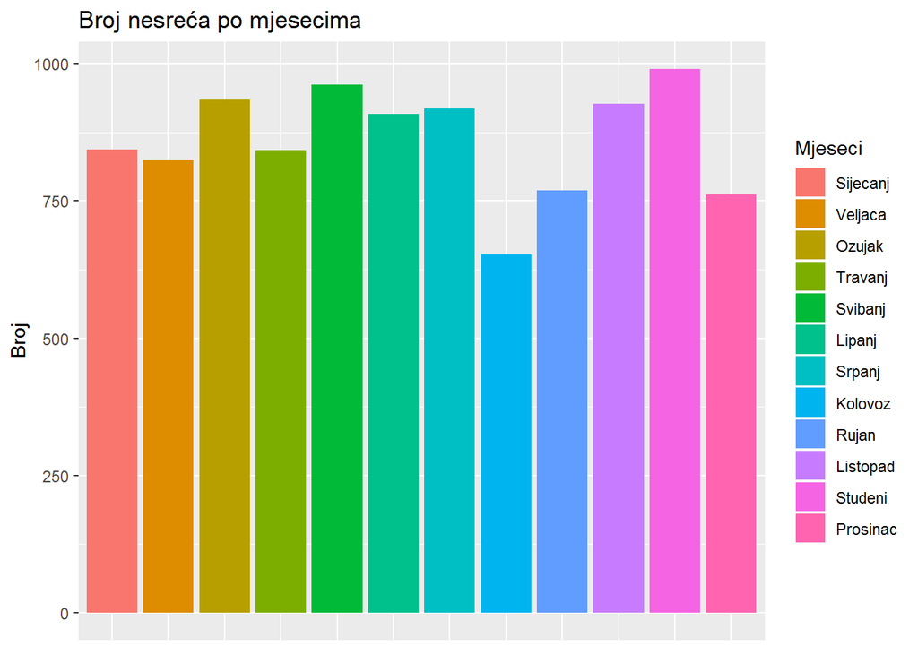

```r
print(distribucijapomjesecima)
```

Iz grafa se može primjetiti kako je broj nesreća u Barceloni bio najmanji u kolovozu, a u preostalim mjesecima je bio otprilike jednak te sa malim odstupanjima u studenom i prosincu. Razlog ne znamo, ali može se pretpostaviti da je povezano sa turizmom u Barceloni.

#### Broj nesreća po danima u tjednu

```r
nesrece_dan = nesrece %>%
                    select(Id, Weekday) %>%
                    group_by(Id) %>%
                    distinct() %>%
  mutate(Weekday=factor(Weekday, levels=c("Monday","Tuesday","Wednesday","Thursday","Friday","Saturday","Sunday")))

datatable(head(nesrece_dan))
```

|  | Id | Weekday |
| --- | --- | --- |
| 1 | 2017S008429 | Friday |
| 2 | 2017S007316 | Friday |
| 3 | 2017S010210 | Friday |
| 4 | 2017S006364 | Friday |
| 5 | 2017S004615 | Thursday |
| 6 | 2017S007775 | Wednesday |

```r
summary(nesrece_dan$Weekday) #broj nesreca po mjesecima
```

```
##    Monday   Tuesday Wednesday  Thursday    Friday  Saturday    Sunday
##      1509      1691      1650      1675      1760      1155       895
```

```r
distribucijapodanima  = ggplot(data = nesrece_dan) +
                geom_bar(mapping = aes(x = factor(Weekday,levels=c("Monday","Tuesday","Wednesday","Thursday","Friday","Saturday","Sunday")), y = ..count.., fill = Weekday)) +
                labs(title = 'Broj nesreća po danima u tjednu',y='Broj') +
                scale_fill_brewer(palette = 'Set2') +
                scale_fill_discrete(name='Dani u tjednu',labels=c("Ponedeljak","Utorak","Srijeda","Četvrtak","Petak","Subota","Nedelja"))+ scale_x_discrete(limits=c("Monday","Tuesday","Wednesday","Thursday","Friday","Saturday","Sunday"))+
  theme(axis.title.x=element_blank(),
        axis.text.x=element_blank(),
        axis.ticks.x=element_blank())
```

```
## which will replace the existing scale.
```

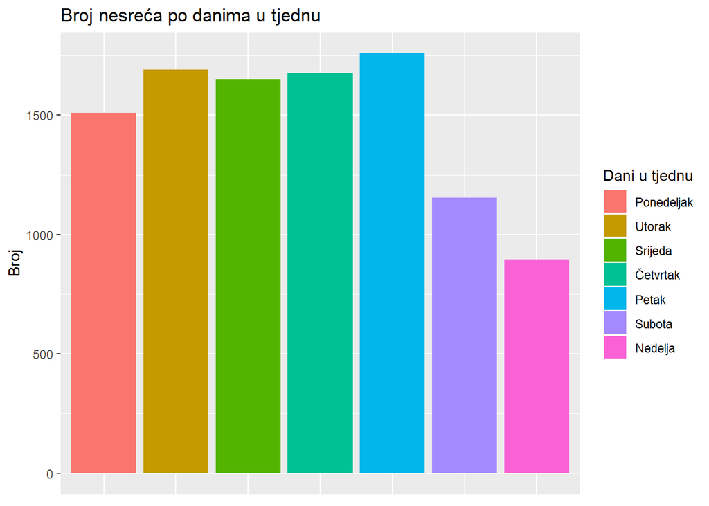

```r
print(distribucijapodanima)
```

Možemo primjetiti kako je najmanje nesreća tokom vikenda, a najviše u petak. Detaljnijom analizom društvene klime Barcelone, moglo bi se utvrditi razlog tome.

#### Broj nesreća prema dijelu dana

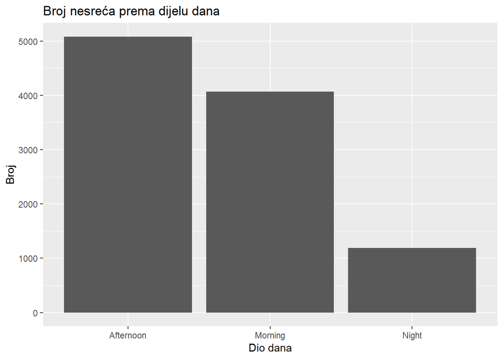

```r
ggplot(data = nesrece) +
   geom_bar(mapping = aes(x = Part.of.the.day))+labs(title = 'Broj nesreća prema dijelu dana',y='Broj',x='Dio dana')+scale_fill_discrete(limits=c("Prijepodne","Ujutro","Navečer"))
```

Možemo primjetiti da se najveći broj nesreća dogodio u poslijepodnevnim satima, što se može objasniti sa povećanom prometnom aktivnosti zbog kraja radnog vremena.

#### Broj nesreća prema satu

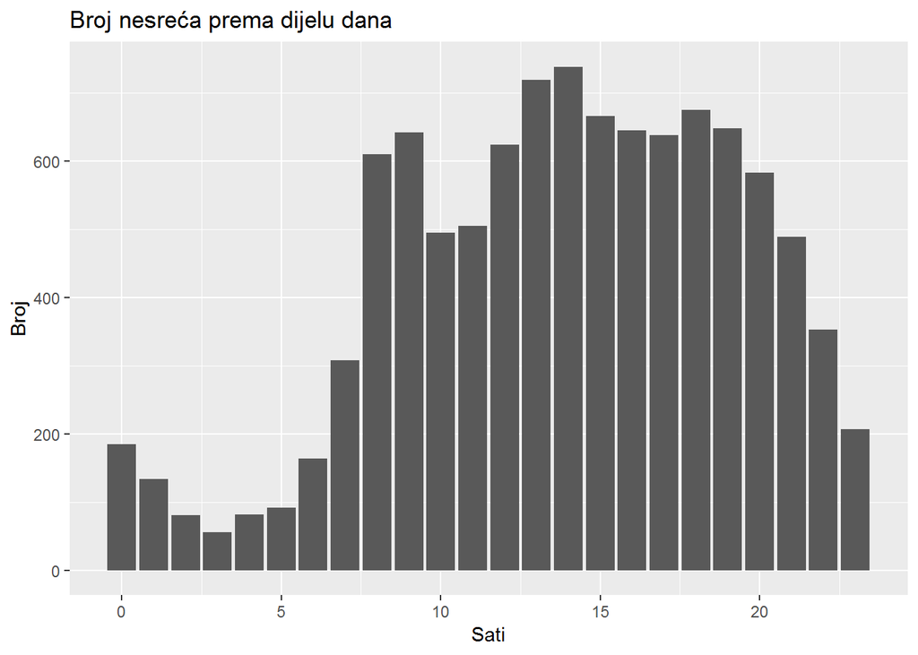

```r
ggplot(data = nesrece) +
   geom_bar(mapping = aes(x = Hour))+labs(title = 'Broj nesreća prema dijelu dana',y='Broj',x='Sati')
```